# assignment1_2017250101_101_lee

# 1. Loading the data

```r
d <- read.delim("DDG2P_24_9_2019.with_pLI.txt")
```

# 2. Draw the plot

We will draw two plots: 1) pLI score by allelic requirement and 2) pLI score by DDD category. For this, we will use the ridgeline plot.

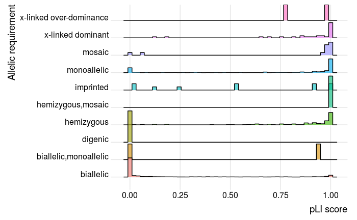

```r
library(ggridges)
library(ggplot2)

#Draw the first plot: pLI score by allelic requirement

p1 <- d %>% filter(allelic.requirement != "NA") %>%
  ggplot(aes(x = pLI, y = allelic.requirement, fill = allelic.requirement)) +
  geom_density_ridges(alpha=0.6, stat="binline", bins=50)+
  theme_ridges() +
  theme(
    legend.position = "none",
    panel.spacing = unit(0.1, "lines")) +
  xlab("pLI score")+
  ylab("Allelic requirement")

p1
```

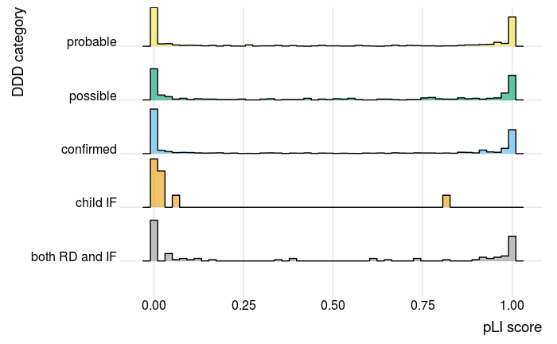

```r
#For this time, in order to change the figure color and also make the plot colorblind friendly, lets define the cbPalette and use it to fill the figure.

cbPalette <- c("#999999", "#E69F00", "#56B4E9", "#009E73", "#F0E442", "#0072B2", "#D55E00", "#CC79A7")

p2 <- ggplot(d, aes(x = pLI, y = DDD.category, fill = DDD.category)) +
  scale_fill_manual(values=cbPalette)+
  geom_density_ridges(scale=0.9, alpha=0.6, stat="binline", bins=50)+
  theme_ridges() +
  theme(
    legend.position = "none",
    panel.spacing = unit(0.1, "lines")) +
  xlab("pLI score")+
  ylab("DDD category")


#Because the plots touches a line a lot above, we've changed a scale of the plot to 0.9. Scale, one of the aesthetics, is a scaling factor to scale the height of the ridgelines relative to the spacing between them. A value of 1 indicates that the maximum point of any ridgeline touches the baseline right above, assuming even spacing between baselines.

p2
```

# 3. Merge the plots

We will merge the previous two plots using the function `cowplot`.

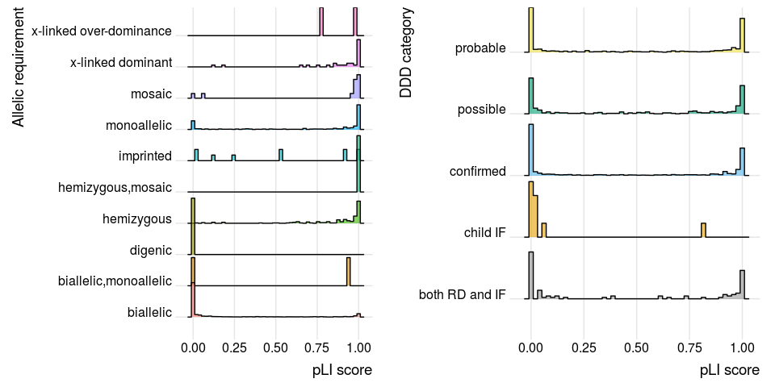

```r
library(cowplot)
p<-plot_grid(p1,p2,ncol=2)
p
```

# 4. Explanation

Fisrt, let’s define the several terms related to the plot. These definition is from DECIPHER, the source of the raw data of the above plots.

x-linked dominant: Plausible disease-causing mutations identified one copy of the X chromosome in females as a cause of a specific developmental disorder, includes disorders where heterozygous females and hemizygous males are similarly affected (e.g. SMC1A mutations)

mosaic: Plausible disease-causing mutations identified on one allele in a proportion of cells with the others being wild-type as a cause of a specific developmental disorder

imprinted: Plausible disease-causing mutations identified on one allele with the parent of origin determining the specific developmental disorder

digenic: Plausible disease-causing mutations identified on one or both alleles of two different genes causing a specific developmental disorder where similar mutations of either gene would not

monoallelic: Plausible disease-causing mutations identified on one allele in all or the vast majority of with specific developmental disorder

biallelic: Plausible disease-causing homozygous or compound heterozygous mutations identified on both alleles in the majority of with specific developmental disorder

hemizygous: Plausible disease-causing mutations identified on the X chromosome in a male as a cause of a specific developmental disorder, the disorder being predominantly recessive in female carriers

Confirmed DD Gene: 1) Plausible disease-causing mutations within, affecting or encompassing an interpretable functional region of a single gene identified in multiple (>3) unrelated cases/families with a developmental disorder 2) Plausible disease-causing mutations within, affecting or encompassing cis-regulatory elements convincingly affecting the expression of a single gene identified in multiple (>3) unrelated cases/families with a developmental disorder 3) As definition 1 and 2 of Probable DD Gene (see below) with addition of convincing bioinformatic or functional evidence of causation (e.g. known inborn error of metabolism with mutation in orthologous gene which is known to have the relevant deficient enzymatic activity in other species; existence of animal mode which recapitulates the human phenotype)

Probable DD Gene: 1) Plausible disease-causing mutations within, affecting or encompassing an interpretable functional region of a single gene identified in more than one (2 or 3) unrelated cases/families or segregation within multiple individuals within a single large family with a developmental disorder 2) Plausible disease-causing mutations within, affecting or encompassing cis-regulatory elements convincingly affecting the expression of a single gene identified in in more than one (2 or 3) unrelated cases/families with a developmental disorder 3) As definitions of Possible DD Gene (see below) with addition of convincing bioinformatic or functional evidence of causation (e.g. known inborn error of metabolism with mutation in orthologous gene which is known to have the relevant deficient enzymatic activity in other species; existence of animal mode which recapitulates the human phenotype)

Possible DD Gene: 1) Plausible disease-causing mutations within, affecting or encompassingan interpretable functional region of a single gene identified in one case or segregation within multiple individuals within a small family with a developmental disorder 2) Plausible disease-causing mutations within, affecting or encompassing cis-regulatory elements convincingly affecting the expression of a single gene identified in one case/family with a developmental disorder 3) Possible disease-causing mutations within, affecting or encompassing an interpretable functional region of a single gene identified in more than one unrelated cases/families or segregation within multiple individuals within a single large family with a developmental disorder

Not DD Gene: No plausible disease-causing mutations within, affecting or encompassing the coding region in a developmental disorder AND not an IF gene

Both DD and IF: Plausible disease-causing mutations within, affecting or encompassing the coding region of a single gene identified in multiple (>3) unrelated cases/families with both a developmental disorder and an incidental (nondevelopmental) disorder

Now let’s begin to understand the plot. The pLI score, which is computed from Exome Aggregation Consortium (ExAC), indicates the probability that a gene is intolerant to a Loss of Function (LoF) mutation. Genes with high pLI scores (pLI ≥ 0.9) are extremely LoF intolerant, whereby genes with low pLI scores (pLI ≤ 0.1) are LoF tolerant.

We can understand this result related to the definition of Haplosufficient category. According to Medicinenet, the Haplosufficient category is defined as:

1. A situation in which the total level of a gene product (a particular protein) produced by the cell is about half of the normal level and that is not sufficient to permit the cell to function normally.
2. A condition that arises when the normal phenotype requires the protein product of both alleles, and reduction of 50% of gene function results in an abnormal phenotype.

Moreover, we can see the plot in the right - pLI score by DDD category. DDD is Deciphering Developmental Disorders, and as you could realize from the definition of the DDD category terms above, the DDD category is the level of certainty that the gene causes developmental disease. As you see the plot, except ‘child IF’ category, the pLI scores of the categories are polarized from end to end. This states that even though it can easily be expected that the high pLI score would lead to high DDD probability because DDD is shown by the abnormal phenotype, the pLI score and the DDD probability do not have positive correlation. More accurately, as the pLI scores are highly polarized, there would be more than one other etiology that cause DDD, not only LoF.